# Twin models

Klaus Holst & Thomas Scheike

This document provides a brief tutorial to analyzing twin data using the **`mets`** package:

$$\newcommand{\cov}{\mathbb{C}\text{ov}}
\newcommand{\cor}{\mathbb{C}\text{or}}
\newcommand{\var}{\mathbb{V}\text{ar}}
\newcommand{\E}{\mathbb{E}}
\newcommand{\unitfrac}[2]{#1/#2}
\newcommand{\n}{}$$

# Twin analysis, continuous traits

In the following we examine the heritability of Body Mass Index<sup>korkeila_bmi_1991</sup> <sup>hjelmborg_bmi_2008</sup>, based on data on self-reported BMI-values from a random sample of 11,411 same-sex twins. First, we will load data

```r
library(mets)
data("twinbmi")
head(twinbmi)
```

```
#>   tvparnr      bmi      age gender zyg id num
#> 1       1 26.33289 57.51212   male  DZ  1   1
#> 2       1 25.46939 57.51212   male  DZ  1   2
#> 3       2 28.65014 56.62696   male  MZ  2   1
#> 5       3 28.40909 57.73097   male  DZ  3   1
#> 7       4 27.25089 53.68683   male  DZ  4   1
#> 8       4 28.07504 53.68683   male  DZ  4   2
```

The data is on *long* format with one subject per row.

- **`tvparnr`:** twin id
- **`bmi`:** Body Mass Index ($\mathrm{kg}/{\mathrm{m}^2}$)
- **`age`:** Age (years)
- **`gender`:** Gender factor (male,female)
- **`zyg`:** zygosity (MZ, DZ)

We transpose the data allowing us to do pairwise analyses

```r
twinwide <- fast.reshape(twinbmi, id="tvparnr",varying=c("bmi"))
head(twinwide)
```

```
#>    tvparnr     bmi1      age gender zyg id num     bmi2
#> 1        1 26.33289 57.51212   male  DZ  1   1 25.46939
#> 3        2 28.65014 56.62696   male  MZ  2   1       NA
#> 5        3 28.40909 57.73097   male  DZ  3   1       NA
#> 7        4 27.25089 53.68683   male  DZ  4   1 28.07504
#> 9        5 27.77778 52.55838   male  DZ  5   1       NA
#> 11       6 28.04282 52.52231   male  DZ  6   1 22.30936
```

Next we plot the association within each zygosity group

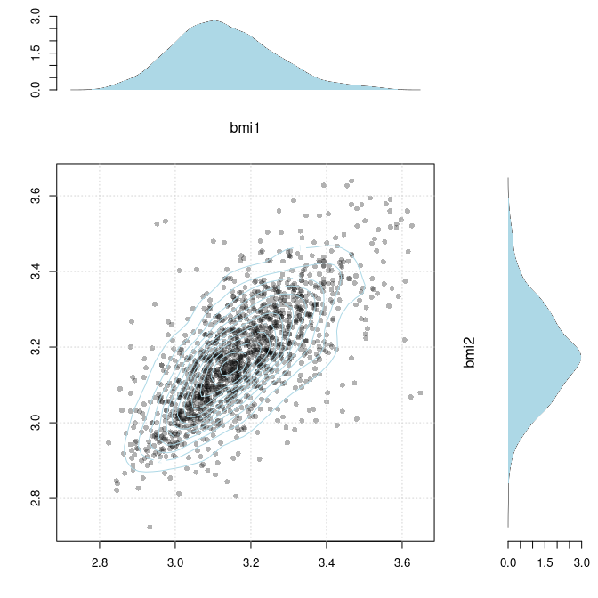

Scatter plot of logarithmic BMI measurements in MZ twins

```r
mz <- log(subset(twinwide, zyg=="MZ")[,c("bmi1","bmi2")])
plot_twin(mz)
```

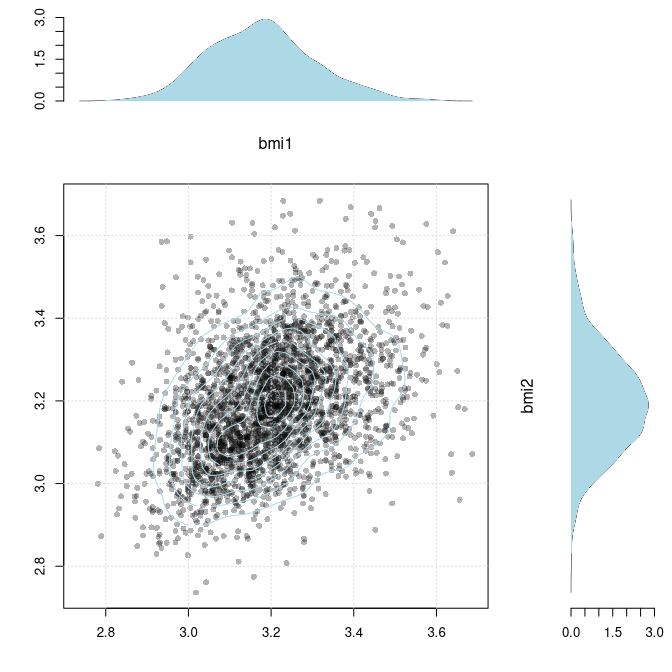

Scatter plot of logarithmic BMI measurements in DZ twins

```r
dz <- log(subset(twinwide, zyg=="DZ")[,c("bmi1","bmi2")])
plot_twin(dz)
```

The plots and raw association measures show considerably stronger dependence in the MZ twins, indicating genetic influence on the trait.

```r
cor.test(mz[,1],mz[,2], method="spearman")
```

```
#>
#>  Spearman's rank correlation rho
#>
#> data:  mz[, 1] and mz[, 2]
#> S = 165457624, p-value < 2.2e-16
#> alternative hypothesis: true rho is not equal to 0
#> sample estimates:
#>       rho
#> 0.6956209
```

```r
cor.test(dz[,1],dz[,2], method="spearman")
```

```
#>
#>  Spearman's rank correlation rho
#>
#> data:  dz[, 1] and dz[, 2]
#> S = 2162514570, p-value < 2.2e-16
#> alternative hypothesis: true rho is not equal to 0
#> sample estimates:
#>       rho
#> 0.4012686
```

Next we examine the marginal distribution (GEE model with working independence):

```r
l0 <- lm(bmi ~ gender + I(age-40), data=twinbmi)
estimate(l0, id=twinbmi$tvparnr)
```

```
#>             Estimate  Std.Err    2.5%   97.5%    P-value
#> (Intercept)  23.3687 0.054534 23.2618 23.4756  0.000e+00
#> gendermale    1.4077 0.073216  1.2642  1.5512  2.230e-82
#> I(age - 40)   0.1177 0.004787  0.1083  0.1271 1.499e-133
```

```r
library("splines")
l1 <- lm(bmi ~ gender*ns(age,3), data=twinbmi)
marg1 <- estimate(l1, id=twinbmi$tvparnr)
```

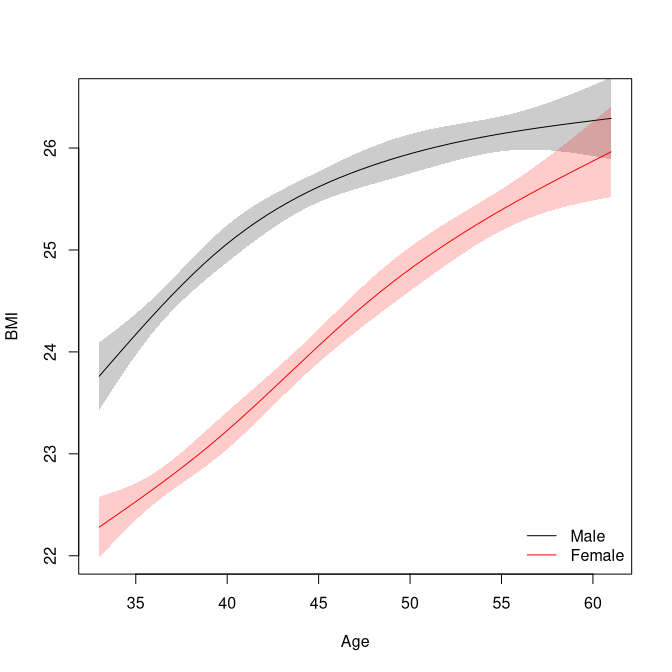

Marginal association between BMI and Age for males and females.

```r
dm <- lava::Expand(twinbmi,
        bmi=0,
        gender=c("male"),
        age=seq(33,61,length.out=50))
df <- lava::Expand(twinbmi,
        bmi=0,
        gender=c("female"),
        age=seq(33,61,length.out=50))

plot(marg1, function(p) model.matrix(l1,data=dm)%*%p,
     data=dm["age"], ylab="BMI", xlab="Age",
     ylim=c(22,26.5))
plot(marg1, function(p) model.matrix(l1,data=df)%*%p,
     data=df["age"], col="red", add=TRUE)
legend("bottomright", c("Male","Female"),
       col=c("black","red"), lty=1, bty="n")
```

## Polygenic model

We can decompose the trait into the following variance components

$$\begin{align*}
Y_i = A_i + D_i + C + E_i, \quad i=1,2
\end{align*}$$

- **$A$:** Additive genetic effects of alleles
- **$D$:** Dominant genetic effects of alleles
- **$C$:** Shared environmental effects
- **$E$:** Unique environmental effects

Dissimilarity of MZ twins arises from unshared environmental effects only, $\cor(E_1,E_2)=0$ and

$$\begin{align*}
\cor(A_1^{MZ},A_2^{MZ}) = 1, \quad
\cor(D_1^{MZ},D_2^{MZ}) = 1,
\end{align*}$$

$$\begin{align*}
\cor(A_1^{DZ},A_2^{DZ}) = 0.5, \quad
\cor(D_1^{DZ},D_2^{DZ}) = 0.25,
\end{align*}$$

$$\begin{align*}
Y_i = A_i + C_i + D_i + E_i
\end{align*}$$

$$\begin{align*}
A_i \sim\mathcal{N}(0,\sigma_A^2), C_i
\sim\mathcal{N}(0,\sigma_C^2), D_i
\sim\mathcal{N}(0,\sigma_D^2),
E_i \sim\mathcal{N}(0,\sigma_E^2)
\end{align*}$$

$$\begin{gather*}
\cov(Y_{1},Y_{2}) = \\
\begin{pmatrix}
\sigma_A^2 & 2\Phi\sigma_A^2 \\
2\Phi\sigma_A^2 & \sigma_A^2
\end{pmatrix} +
\begin{pmatrix}
\sigma_C^2 & \sigma_C^2 \\
\sigma_C^2 & \sigma_C^2
\end{pmatrix} +
\begin{pmatrix}
\sigma_D^2 & \Delta_{7}\sigma_D^2 \\
\Delta_{7}\sigma_D^2 & \sigma_D^2
\end{pmatrix} +
\begin{pmatrix}
\sigma_E^2 & 0 \\
0 & \sigma_E^2
\end{pmatrix}
\end{gather*}$$

```r
dd <- na.omit(twinbmi)
```

Saturated model (different marginals in MZ and DZ twins and different marginals for twin 1 and twin 2):

```r
l0 <- twinlm(bmi ~ age+gender, data=dd, DZ="DZ", zyg="zyg", id="tvparnr", type="sat")
```

Different marginals for MZ and DZ twins (but same marginals within a pair)

```r
lf <- twinlm(bmi ~ age+gender, data=dd,DZ="DZ", zyg="zyg", id="tvparnr", type="flex")
```

Same marginals but free correlation with MZ, DZ

```r
lu <- twinlm(bmi ~ age+gender, data=dd, DZ="DZ", zyg="zyg", id="tvparnr", type="eqmarg")
estimate(lu)
```

```
#>                      Estimate  Std.Err    2.5%   97.5%    P-value
#> bmi.1@1               18.6037 0.251036 18.1116 19.0957  0.000e+00
#> bmi.1~age.1@1          0.1189 0.005635  0.1078  0.1299  9.177e-99
#> bmi.1~gendermale.1@1   1.3848 0.086573  1.2151  1.5544  1.376e-57
#> log(var)@1             2.4424 0.022095  2.3991  2.4857  0.000e+00
#> atanh(rhoMZ)@1         0.7803 0.036249  0.7092  0.8513 9.008e-103
#> atanh(rhoDZ)@2         0.2987 0.020953  0.2576  0.3397  4.288e-46
```

A formal test of genetic effects can be obtained by comparing the MZ and DZ correlation:

```r
estimate(lu,lava::contr(5:6,6))
```

```
#>                           Estimate Std.Err   2.5%  97.5%   P-value
#> [atanh(rhoMZ)@1] - [a....   0.4816 0.04177 0.3997 0.5635 9.431e-31
```

We also consider the ACE model

```r
ace0 <- twinlm(bmi ~ age+gender, data=dd, DZ="DZ", zyg="zyg", id="tvparnr", type="ace")
summary(ace0)
```

```
#>                  Estimate Std. Error Z value Pr(>|z|)
#> bmi            1.8599e+01 2.5576e-01  72.720   <2e-16
#> sd(A)          2.7270e+00 4.2658e-02  63.927   <2e-16
#> sd(C)          1.7123e-06 3.1064e-01   0.000        1
#> sd(E)          2.0276e+00 3.4787e-02  58.286   <2e-16
#> bmi~age        1.1892e-01 5.6246e-03  21.142   <2e-16
#> bmi~gendermale 1.3846e+00 8.8748e-02  15.601   <2e-16
#>
#> MZ-pairs DZ-pairs
#>     1483     2788
#>
#> Variance decomposition:
#>   Estimate 2.5%    97.5%
#> A 0.64399  0.61793 0.67005
#> C 0.00000  0.00000 0.00000
#> E 0.35601  0.32995 0.38207
#>
#>
#>                          Estimate 2.5%    97.5%
#> Broad-sense heritability 0.64399  0.61793 0.67005
#>
#>                        Estimate 2.5%    97.5%
#> Correlation within MZ: 0.64399  0.61718 0.66931
#> Correlation within DZ: 0.32200  0.30890 0.33497
#>
#> 'log Lik.' -22019.66 (df=6)
#> AIC: 44051.32
#> BIC: 44089.47
```

# Bibliography

[korkeila_bmi_1991] Korkeila, Kaprio, Rissanen & Koskenvuo, Effects of gender and age on the heritability of body mass index, *Int J Obes*, **15(10)**, 647-654 (1991). ↩︎

[hjelmborg_bmi_2008] Hjelmborg, Fagnani, Silventoinen, McGue, Korkeila, Christensen, Rissanen & Kaprio, Genetic influences on growth traits of BMI: a longitudinal study of adult twins, *Obesity (Silver Spring)*, **16(4)**, 847-852 (2008). ↩︎